# Long Assignment: Churn Data

# Business Understanding

1. Business Background
2. Bussiness Objectives
3. Business Success Criteria
4. Machine Learning Problem

### 1. Business Background

A perda de clientes nas telecomunicações, ou a desistência de clientes, ocorre quando os subscritores deixam de utilizar um serviço de telecomunicações ou mudam de fornecedores. É uma métrica vital para as empresas de telecomunicações, refletindo a perda de clientes e impactando a receita. Para mitigar o impacto financeiro, as empresas recorrem a sistemas preditivos para identificar possíveis desistências e lançar campanhas direcionadas de retenção, uma vez que a retenção de clientes é economicamente eficaz. A indústria das telecomunicações evolui rapidamente, e através da análise dos padrões de utilização dos clientes, é possível antecipar mudanças.

### 2. Bussiness Objectives

O objetivo deste projeto é analisar, processar os dados e desenvolver modelos preditivos para uma previsão precisa de desistência. Isto significa que o objetivo empresarial, neste caso, é prever corretamente se um cliente irá ou não desistir da empresa.

### 3. Business Success Criteria

Os critérios de sucesso empresarial para uma empresa de telecomunicações consistem em reduzir a taxa de desistência, retendo mais clientes e, dessa forma, diminuir o impacto financeiro na empresa. Uma hipótese é, por exemplo, alcançar uma redução de 20% na taxa de desistência de clientes de telecomunicações nos próximos 12 meses, implementando e otimizando sistemas preditivos. Esta redução será indicativa de uma melhoria na retenção de clientes, mitigação do impacto financeiro e uma resposta proativa às tendências em evolução nas telecomunicações. Além disso, também é importante manter a eficácia financeira garantindo que os custos de retenção de clientes existentes permaneçam inferiores aos de adquirir novos clientes.

### 4. Machine Learning Problem/Solution

O objetivo é desenvolver e otimizar um sistema preditivo capaz de prever quais clientes têm probabilidade de desistir nos próximos 12 meses (ou em qualquer outro período de tempo específico). O problema específico envolve a construção de um modelo que consiga identificar com precisão potenciais desistentes, permitindo à empresa implementar estratégias direcionadas de retenção. A solução de aprendizado de máquina visa contribuir para alcançar os critérios de sucesso empresarial, nomeadamente uma redução de 20% na taxa de desistência de clientes de telecomunicações, conduzindo a uma melhoria na retenção de clientes e mitigação do impacto financeiro.

# Data Understanding

A partir deste ponto, procedeu-se à exploração do conjunto de dados de modo a visualizar as diferentes variáveis e compreender possíveis padrões relevantes, com o intuito de extrair perceções(insights).

```python
import warnings
warnings.filterwarnings("ignore")
import pandas as pd
df=pd.read_csv('churn_data.csv')
df
```

|  | churn | accountlength | internationalplan | voicemailplan | numbervmailmessages | totaldayminutes | totaldaycalls | totaldaycharge | totaleveminutes | totalevecalls | totalevecharge | totalnightminutes | totalnightcalls | totalnightcharge | totalintlminutes | totalintlcalls | totalintlcharge | numbercustomerservicecalls |
| --- | --- | --- | --- | --- | --- | --- | --- | --- | --- | --- | --- | --- | --- | --- | --- | --- | --- | --- |
| 0 | No | 128.0 | no | yes | 25.0 | 265.1 | 110.0 | 45.07 | 197.4 | 99.0 | 16.78 | 244.7 | 91.0 | 11.01 | 10.0 | 3.0 | 2.70 | 1.0 |
| 1 | No | 107.0 | no | yes | 26.0 | 161.6 | 123.0 | 27.47 | 195.5 | 103.0 | 16.62 | 254.4 | 103.0 | 11.45 | 13.7 | 3.0 | 3.70 | 1.0 |
| 2 | No | 137.0 | no | no | 0.0 | 243.4 | NaN | 41.38 | 121.2 | 110.0 | 10.30 | 162.6 | 104.0 | 7.32 | 12.2 | 5.0 | 3.29 | 0.0 |
| 3 | No | 84.0 | yes | no | 0.0 | 299.4 | 71.0 | 50.90 | 61.9 | 88.0 | 5.26 | 196.9 | 89.0 | 8.86 | 6.6 | 7.0 | 1.78 | 2.0 |
| 4 | No | 75.0 | yes | no | 0.0 | 166.7 | 113.0 | 28.34 | 148.3 | 122.0 | 12.61 | 186.9 | 121.0 | 8.41 | 10.1 | 3.0 | 2.73 | 3.0 |
| ... | ... | ... | ... | ... | ... | ... | ... | ... | ... | ... | ... | ... | ... | ... | ... | ... | ... | ... |
| 4995 | No | 50.0 | no | yes | 40.0 | 235.7 | 127.0 | 40.07 | 223.0 | 126.0 | 18.96 | 297.5 | 116.0 | 13.39 | 9.9 | 5.0 | 2.67 | 2.0 |
| 4996 | Yes | 152.0 | no | no | 0.0 | 184.2 | 90.0 | 31.31 | 256.8 | 73.0 | 21.83 | 213.6 | 113.0 | 9.61 | 14.7 | 2.0 | 3.97 | 3.0 |
| 4997 | No | 61.0 | no | no | 0.0 | 140.6 | 89.0 | 23.90 | 172.8 | 128.0 | 14.69 | 212.4 | 97.0 | 9.56 | 13.6 | 4.0 | 3.67 | 1.0 |
| 4998 | No | 109.0 | no | no | 0.0 | 188.8 | 67.0 | 32.10 | 171.7 | 92.0 | 14.59 | 224.4 | 89.0 | NaN | 8.5 | 6.0 | 2.30 | 0.0 |
| 4999 | No | 86.0 | no | yes | 34.0 | 129.4 | 102.0 | 22.00 | 267.1 | 104.0 | 22.70 | 154.8 | 100.0 | 6.97 | 9.3 | 16.0 | 2.51 | 0.0 |

5000 rows × 18 columns

```python
df.info()
```

```
<class 'pandas.core.frame.DataFrame'>
RangeIndex: 5000 entries, 0 to 4999
Data columns (total 18 columns):
 #   Column                      Non-Null Count  Dtype
---  ------                      --------------  -----
 0   churn                       5000 non-null   object
 1   accountlength               4951 non-null   float64
 2   internationalplan           4950 non-null   object
 3   voicemailplan               4950 non-null   object
 4   numbervmailmessages         4950 non-null   float64
 5   totaldayminutes             4950 non-null   float64
 6   totaldaycalls               4950 non-null   float64
 7   totaldaycharge              4950 non-null   float64
 8   totaleveminutes             4950 non-null   float64
 9   totalevecalls               4950 non-null   float64
 10  totalevecharge              4950 non-null   float64
 11  totalnightminutes           4950 non-null   float64
 12  totalnightcalls             4950 non-null   float64
 13  totalnightcharge            4950 non-null   float64
 14  totalintlminutes            4950 non-null   float64
 15  totalintlcalls              4950 non-null   float64
 16  totalintlcharge             4950 non-null   float64
 17  numbercustomerservicecalls  4950 non-null   float64
dtypes: float64(15), object(3)
memory usage: 703.3+ KB
```

```python
df.count()/df.shape[0]
```

```
churn                         1.0000
accountlength                 0.9902
internationalplan             0.9900
voicemailplan                 0.9900
numbervmailmessages           0.9900
totaldayminutes               0.9900
totaldaycalls                 0.9900
totaldaycharge                0.9900
totaleveminutes               0.9900
totalevecalls                 0.9900
totalevecharge                0.9900
totalnightminutes             0.9900
totalnightcalls               0.9900
totalnightcharge              0.9900
totalintlminutes              0.9900
totalintlcalls                0.9900
totalintlcharge               0.9900
numbercustomerservicecalls    0.9900
dtype: float64
```

### Pie-Chart da variável alvo (target) 'churn'

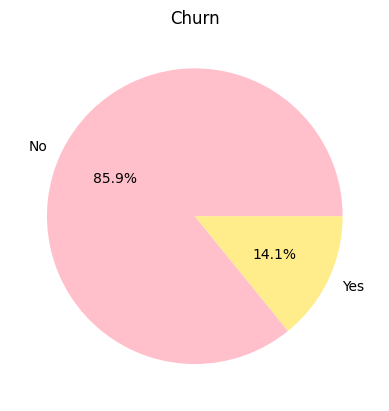

```python
import numpy as np
import matplotlib.pyplot as plt
colors_churn = ['pink', '#FFEC8B']
churn_counts = df['churn'].value_counts()

plt.pie(churn_counts, labels=churn_counts.index, autopct='%1.1f%%', colors=colors_churn)
plt.title('Churn')

plt.show()
```

Devido ao facto de haver muitos mais clientes a continuar a usar o serviço(No) do que a cancelá-lo(Yes), como podemos visualizar neste gráfico, o dataset não é equilibrado. Isto significa que a classe que queremos prever ('Churn' == 'Yes') tem um menor número de linhas comparativamente à outra classe ('Churn' == 'No). Em virtude desta condição, os modelos tendem a favorecer a classe maioritária, resultando num desempenho inferior na previsão da classe minoritária. Métricas como a acurácia podem ser enganosas, pois um modelo pode ter alta acurácia ao prever sempre a classe maioritária, mas pode falhar em generalizar padrões da classe minoritária devido à falta de exemplos dessa classe. Neste caso, o uso de técnicas de geração de dados sintéticos (SMOTE) e um maior ênfase na utilização de medidas de desempenho como precisão, recall, F1-score poderão contribuir para um maior sucesso da performance do modelo usado.

### Opções para lidar com um dataset desiquilibrado

1. Subamostragem (remover exemplos da classe maioritária) ou superamostragem (adicionar exemplos da classe minoritária) para equilibrar as classes.
2. Atribuir pesos diferentes às classes durante o treino do modelo para penalizar mais erros na classe maioritária.
3. Usar técnicas como SMOTE (Synthetic Minority Over-sampling Technique) para gerar exemplos sintéticos da classe minoritária.
4. Usar métricas de avaliação apropriadas para conjuntos de dados desequilibrados, como precisão, recall, F1-score, em vez de depender apenas da acurácia.
5. Algoritmos como Random Forests, SVMs com custos diferenciados, etc.

```python
df_num = df[['accountlength', 'numbervmailmessages', 'totaldayminutes', 'totaldaycalls', 'totaldaycharge', 'totaleveminutes',
               'totalevecalls', 'totalevecharge', 'totalnightminutes', 'totalnightcalls', 'totalnightcharge', 'totalintlminutes',
              'totalintlcalls', 'totalintlcharge', 'numbercustomerservicecalls']]
```

### Distribuição das variáveis numéricas

(com missing values)

```
array([[<Axes: title={'center': 'accountlength'}>,
        <Axes: title={'center': 'numbervmailmessages'}>,
        <Axes: title={'center': 'totaldayminutes'}>,
        <Axes: title={'center': 'totaldaycalls'}>],
       [<Axes: title={'center': 'totaldaycharge'}>,
        <Axes: title={'center': 'totaleveminutes'}>,
        <Axes: title={'center': 'totalevecalls'}>,
        <Axes: title={'center': 'totalevecharge'}>],
       [<Axes: title={'center': 'totalnightminutes'}>,
        <Axes: title={'center': 'totalnightcalls'}>,
        <Axes: title={'center': 'totalnightcharge'}>,
        <Axes: title={'center': 'totalintlminutes'}>],
       [<Axes: title={'center': 'totalintlcalls'}>,
        <Axes: title={'center': 'totalintlcharge'}>,
        <Axes: title={'center': 'numbercustomerservicecalls'}>, <Axes: >]],
      dtype=object)
```

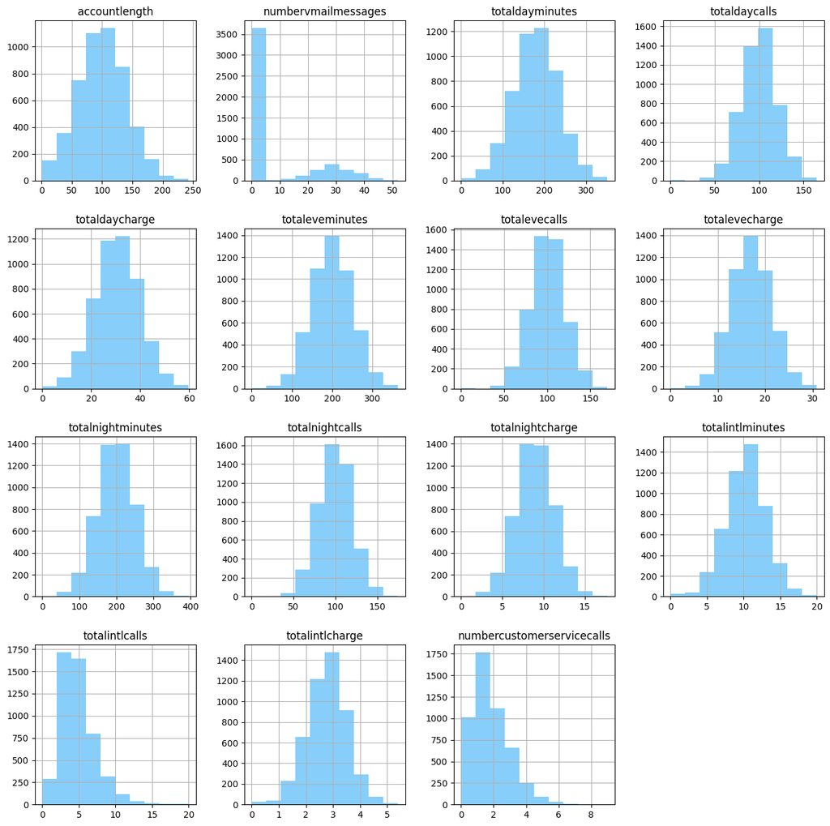

```python
df_num.hist(figsize=(16,16), color = 'lightskyblue')
```

### Variáveis nominais

As colunas 'internationalplan' e 'voicemailplan' possuem 50 missing values cada, o que totalizam 100 valores nulos em 5000 observações, 2% da amostra. Por ser um número relativamente pequeno, decidimos ignorar estes valores. Caso optemos por um modelo que não lide bem com missing values, as observações correspondentes serão descartadas.

```python
df[df['internationalplan'].isna()]
```

|  | churn | accountlength | internationalplan | voicemailplan | numbervmailmessages | totaldayminutes | totaldaycalls | totaldaycharge | totaleveminutes | totalevecalls | totalevecharge | totalnightminutes | totalnightcalls | totalnightcharge | totalintlminutes | totalintlcalls | totalintlcharge | numbercustomerservicecalls |
| --- | --- | --- | --- | --- | --- | --- | --- | --- | --- | --- | --- | --- | --- | --- | --- | --- | --- | --- |
| 177 | No | 127.0 | NaN | no | 0.0 | 202.1 | 103.0 | 34.36 | 229.4 | 86.0 | 19.50 | 195.2 | 113.0 | 8.78 | 11.5 | 3.0 | 3.11 | 2.0 |
| 304 | No | 136.0 | NaN | no | 0.0 | 92.0 | 117.0 | 15.64 | 253.6 | 77.0 | 21.56 | 214.1 | 90.0 | 9.63 | 10.3 | 10.0 | 2.78 | 1.0 |
| 552 | Yes | 44.0 | NaN | no | 0.0 | 288.1 | 112.0 | 48.98 | 258.0 | 92.0 | 21.93 | 192.4 | 90.0 | 8.66 | 10.2 | 4.0 | 2.75 | 3.0 |
| 558 | Yes | 74.0 | NaN | no | 0.0 | 174.1 | 96.0 | 29.60 | 251.1 | 94.0 | 21.34 | 257.6 | 123.0 | 11.59 | 8.3 | 5.0 | 2.24 | 2.0 |
| 560 | No | 80.0 | NaN | no | 0.0 | 160.6 | 103.0 | 27.30 | 237.0 | 109.0 | 20.15 | 245.1 | 88.0 | 11.03 | 10.7 | 1.0 | 2.89 | 1.0 |
| 662 | No | 63.0 | NaN | no | 0.0 | 211.2 | 80.0 | 35.90 | 237.7 | 93.0 | 20.20 | 259.2 | 58.0 | 11.66 | 12.3 | 2.0 | 3.32 | 0.0 |
| 795 | No | 92.0 | NaN | no | 0.0 | 197.0 | 84.0 | 33.49 | 269.3 | 105.0 | 22.89 | 158.9 | 105.0 | 7.15 | 10.8 | 4.0 | 2.92 | 1.0 |
| 848 | No | 149.0 | NaN | no | 0.0 | 237.6 | 79.0 | 40.39 | 192.4 | 107.0 | 16.35 | 207.4 | 111.0 | 9.33 | 9.1 | 9.0 | 2.46 | 0.0 |
| 923 | No | 1.0 | NaN | no | 0.0 | 144.8 | 107.0 | 24.62 | 112.5 | 66.0 | 9.56 | 218.7 | 79.0 | 9.84 | 13.8 | 3.0 | 3.73 | 1.0 |
| 1027 | Yes | 161.0 | NaN | no | 0.0 | 194.2 | 106.0 | 33.01 | 249.4 | 105.0 | 21.20 | 254.9 | 129.0 | 11.47 | 12.9 | 1.0 | 3.48 | 1.0 |
| 1349 | No | 71.0 | NaN | yes | NaN | 141.4 | 107.0 | 24.04 | 163.0 | 105.0 | 13.86 | 220.0 | 99.0 | 9.90 | 5.6 | 3.0 | 1.51 | 2.0 |
| 1432 | No | 63.0 | NaN | no | 0.0 | 164.5 | 75.0 | 27.97 | 147.9 | 118.0 | 12.57 | 252.7 | 97.0 | 11.37 | 11.2 | 2.0 | 3.02 | 0.0 |
| 1457 | No | 118.0 | NaN | no | 0.0 | 133.4 | 113.0 | 22.68 | 121.0 | 92.0 | 10.29 | 254.7 | 129.0 | 11.46 | 5.9 | 4.0 | 1.59 | 1.0 |
| 1521 | No | 103.0 | NaN | no | 0.0 | 173.5 | 83.0 | 29.50 | 244.3 | 65.0 | 20.77 | 221.6 | 66.0 | 9.97 | 9.7 | 2.0 | 2.62 | 3.0 |
| 1569 | No | 73.0 | NaN | yes | 31.0 | 194.4 | 104.0 | 33.05 | 176.0 | 84.0 | 14.96 | 230.1 | 110.0 | NaN | 11.5 | 3.0 | 3.11 | 0.0 |
| 1669 | No | 17.0 | NaN | yes | 35.0 | 198.5 | 123.0 | 33.75 | 270.6 | 74.0 | 23.00 | 209.9 | 130.0 | 9.45 | 8.1 | 10.0 | 2.19 | 1.0 |
| 1775 | No | 142.0 | NaN | yes | 24.0 | 239.8 | 103.0 | 40.77 | 285.9 | 65.0 | 24.30 | 256.7 | 106.0 | 11.55 | 9.5 | 4.0 | 2.57 | 0.0 |
| 1857 | Yes | 107.0 | NaN | no | 0.0 | NaN | 101.0 | 37.79 | 286.0 | 111.0 | 24.31 | 249.4 | 117.0 | 11.22 | 12.1 | 4.0 | 3.27 | 1.0 |
| 1990 | No | 99.0 | NaN | no | 0.0 | 140.7 | 88.0 | 23.92 | 210.9 | 98.0 | 17.93 | 229.9 | 125.0 | 10.35 | 12.4 | 4.0 | 3.35 | 2.0 |
| 1993 | No | 86.0 | NaN | no | 0.0 | 216.3 | 96.0 | 36.77 | 266.3 | 77.0 | 22.64 | 214.0 | 110.0 | 9.63 | 4.5 | 3.0 | 1.22 | 0.0 |
| 2018 | No | 153.0 | NaN | yes | 22.0 | 167.7 | 104.0 | 28.51 | 246.8 | 91.0 | 20.98 | 203.9 | 117.0 | 9.18 | 7.5 | 11.0 | 2.03 | 1.0 |
| 2106 | Yes | 128.0 | NaN | yes | 18.0 | 222.1 | 89.0 | 37.76 | 160.6 | 109.0 | 13.65 | 218.8 | 102.0 | 9.85 | 13.6 | 2.0 | 3.67 | 0.0 |
| 2110 | No | 102.0 | NaN | yes | 25.0 | 137.4 | 100.0 | 23.36 | 176.7 | 83.0 | 15.02 | 188.2 | 93.0 | 8.47 | 10.2 | 6.0 | 2.75 | 2.0 |
| 2199 | No | 110.0 | NaN | no | 0.0 | 241.2 | 105.0 | 41.00 | 174.3 | 85.0 | 14.82 | 245.3 | 59.0 | 11.04 | 8.5 | 4.0 | 2.30 | 2.0 |
| 2436 | No | 63.0 | NaN | no | 0.0 | 207.6 | 96.0 | 35.29 | 229.0 | 112.0 | 19.47 | 162.6 | 131.0 | 7.32 | 13.3 | 2.0 | 3.59 | 1.0 |
| 2592 | No | 163.0 | NaN | no | 0.0 | 202.9 | 100.0 | 34.49 | 178.6 | 46.0 | 15.18 | 203.8 | 116.0 | 9.17 | 12.8 | 3.0 | 3.46 | 5.0 |
| 2690 | No | 36.0 | NaN | no | 0.0 | 235.1 | 97.0 | 39.97 | 196.8 | 104.0 | 16.73 | 259.7 | 110.0 | 11.69 | 7.0 | 7.0 | 1.89 | 3.0 |
| 2807 | No | 52.0 | NaN | no | 0.0 | 217.0 | 104.0 | 36.89 | 152.3 | 83.0 | 12.95 | 134.3 | 109.0 | 6.04 | 11.8 | 4.0 | 3.19 | 2.0 |
| 2839 | Yes | 112.0 | NaN | no | 0.0 | 266.0 | 97.0 | 45.22 | 214.6 | 94.0 | 18.24 | 306.2 | 100.0 | 13.78 | 14.2 | 2.0 | 3.83 | 2.0 |
| 2947 | Yes | NaN | NaN | no | 0.0 | 245.8 | 116.0 | 41.79 | 286.7 | 91.0 | 24.37 | 240.7 | 115.0 | 10.83 | 9.0 | 13.0 | NaN | 1.0 |
| 2950 | Yes | 133.0 | NaN | no | 0.0 | 117.8 | 100.0 | 20.03 | 199.2 | 105.0 | 16.93 | 244.1 | 119.0 | 10.98 | 11.8 | 4.0 | 3.19 | 0.0 |
| 3063 | No | 63.0 | NaN | yes | 25.0 | 190.0 | 137.0 | 32.30 | 116.6 | 76.0 | 9.91 | 141.5 | 110.0 | 6.37 | 12.2 | 2.0 | 3.29 | 1.0 |
| 3136 | No | 107.0 | NaN | yes | 36.0 | 96.3 | 83.0 | 16.37 | 179.6 | 91.0 | 15.27 | 166.3 | 121.0 | 7.48 | 10.3 | 2.0 | 2.78 | 1.0 |
| 3298 | No | 83.0 | NaN | no | 0.0 | 78.1 | 70.0 | 13.28 | 239.3 | 115.0 | 20.34 | 144.4 | 112.0 | 6.50 | 12.3 | 4.0 | 3.32 | 1.0 |
| 3395 | Yes | 111.0 | NaN | no | 0.0 | 304.6 | 56.0 | 51.78 | 157.6 | 101.0 | 13.40 | 188.2 | 116.0 | 8.47 | 12.4 | 1.0 | 3.35 | 1.0 |
| 3403 | No | 84.0 | NaN | no | 0.0 | 204.1 | 132.0 | 34.70 | 164.4 | 117.0 | 13.97 | 165.1 | 123.0 | 7.43 | 0.0 | 0.0 | 0.00 | 1.0 |
| 3479 | No | 101.0 | NaN | no | 0.0 | 164.6 | 85.0 | 27.98 | 204.9 | 72.0 | 17.42 | 136.4 | 104.0 | 6.14 | 11.5 | 5.0 | 3.11 | 0.0 |
| 3534 | No | 83.0 | NaN | no | 0.0 | 133.9 | 82.0 | 22.76 | 169.6 | 105.0 | 14.42 | 222.8 | 114.0 | 10.03 | 11.7 | 4.0 | 3.16 | 0.0 |
| 3867 | No | 124.0 | NaN | no | 0.0 | 192.6 | 108.0 | 32.74 | 223.3 | 106.0 | 18.98 | 187.0 | 84.0 | 8.41 | 4.2 | NaN | 1.13 | 1.0 |
| 3997 | No | 68.0 | NaN | no | 0.0 | 141.9 | 112.0 | 24.12 | 166.2 | 94.0 | 14.13 | 223.5 | 77.0 | 10.06 | 9.2 | 6.0 | 2.48 | 1.0 |
| 4110 | No | 100.0 | NaN | no | 0.0 | 156.3 | 82.0 | 26.57 | 259.4 | 91.0 | 22.05 | 143.7 | 93.0 | 6.47 | 8.3 | 7.0 | 2.24 | 5.0 |
| 4267 | No | 56.0 | NaN | yes | 37.0 | 153.7 | 97.0 | 26.13 | 271.4 | 91.0 | 23.07 | 179.0 | 121.0 | 8.06 | 8.3 | 2.0 | 2.24 | 1.0 |
| 4318 | No | 201.0 | NaN | no | 0.0 | 159.9 | 61.0 | 27.18 | 237.3 | 124.0 | 20.17 | 290.2 | 99.0 | 13.06 | 13.4 | 4.0 | 3.62 | 3.0 |
| 4419 | No | 66.0 | NaN | no | 0.0 | 113.9 | 112.0 | 19.36 | 271.8 | 106.0 | 23.10 | 216.7 | 95.0 | 9.75 | 15.6 | 3.0 | 4.21 | 2.0 |
| 4603 | No | 162.0 | NaN | no | 0.0 | 103.3 | 93.0 | 17.56 | 210.6 | 87.0 | 17.90 | 187.2 | 118.0 | 8.42 | 11.4 | 6.0 | 3.08 | 1.0 |
| 4636 | Yes | 136.0 | NaN | yes | 22.0 | 160.3 | 115.0 | 27.25 | 273.2 | 88.0 | 23.22 | 203.2 | 89.0 | 9.14 | 11.7 | 2.0 | 3.16 | 0.0 |
| 4824 | No | 68.0 | NaN | yes | 43.0 | 147.7 | 95.0 | 25.11 | 259.3 | 108.0 | 22.04 | 237.1 | 106.0 | 10.67 | 8.9 | 8.0 | 2.40 | 3.0 |
| 4883 | No | 119.0 | NaN | no | 0.0 | 121.4 | 95.0 | 20.64 | 230.9 | 81.0 | 19.63 | NaN | 103.0 | 7.36 | 13.8 | 4.0 | 3.73 | 2.0 |
| 4934 | No | 120.0 | NaN | no | 0.0 | 198.0 | 101.0 | 33.66 | 190.2 | 74.0 | 16.17 | 241.2 | 105.0 | 10.85 | 8.3 | 10.0 | 2.24 | 4.0 |
| 4940 | No | 89.0 | NaN | no | 0.0 | 242.5 | NaN | 41.23 | 213.3 | 109.0 | 18.13 | 231.0 | 84.0 | 10.40 | 6.3 | 3.0 | 1.70 | 3.0 |

### Visualização das variáveis nominais

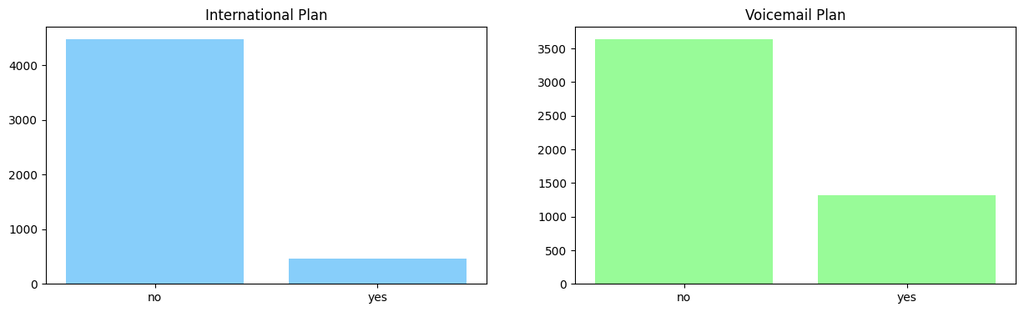

```python
fig, ax = plt.subplots(1, 2, figsize=(15, 4))

# Gráfico de barras para 'internationalplan'
ax[0].bar(df['internationalplan'].value_counts().index, df['internationalplan'].value_counts(), color='lightskyblue')
ax[0].set_title('International Plan')

# Gráfico de barras para 'voicemailplan'
ax[1].bar(df['voicemailplan'].value_counts().index, df['voicemailplan'].value_counts(), color='#98fb98')
ax[1].set_title('Voicemail Plan');
```

Há muitos mais clentes sem plano internacional ou voicemail.

```python
# colunas numéricas do dataset
colunas = ['accountlength', 'numbervmailmessages', 'totaldayminutes', 'totaldaycalls', 'totaldaycharge', 'totaleveminutes',
           'totalevecalls', 'totalevecharge', 'totalnightminutes', 'totalnightcalls', 'totalnightcharge', 'totalintlminutes',
           'totalintlcalls', 'totalintlcharge', 'numbercustomerservicecalls']
```

### Boxplots: visualização de outliers

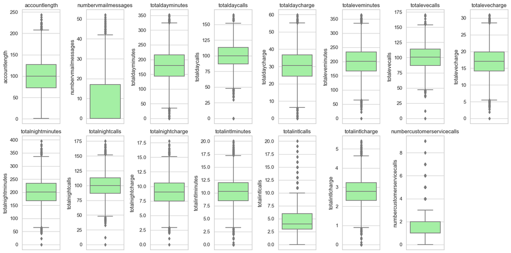

```python
#boxplot para observação de outliers
import seaborn as sns
plt.figure(figsize=(16, 8))
sns.set(style="whitegrid")

for i, coluna in enumerate(colunas, 1):
    plt.subplot(2, 8, i)
    sns.boxplot(y=df[coluna], color='#98fb98')
    plt.title(coluna)

plt.tight_layout()
plt.show();
```

### Criação de uma tabela com a contagem dos outliers

```python
#datasFrame para armazenar a contagem de outliers
contagem_outliers = pd.DataFrame(index=colunas, columns=['Quantidade de Outliers'])

#pra cada variável numérica faz a contagem de quantos outliers há
for coluna in colunas:
    #calcula o intervalo interquartil
    Q1 = df[coluna].quantile(0.25)
    Q3 = df[coluna].quantile(0.75)
    IQR = Q3 - Q1

    #limites para definir outliers
    limite_inferior = Q1 - 1.5 * IQR
    limite_superior = Q3 + 1.5 * IQR

    #conta os outliers
    quantidade_outliers = ((df[coluna] < limite_inferior) | (df[coluna] > limite_superior)).sum()

    #guarda a contagem na tabela
    contagem_outliers.loc[coluna, 'Quantidade de Outliers'] = quantidade_outliers

contagem_outliers
```

|  | Quantidade de Outliers |
| --- | --- |
| accountlength | 24 |
| numbervmailmessages | 60 |
| totaldayminutes | 35 |
| totaldaycalls | 35 |
| totaldaycharge | 36 |
| totaleveminutes | 42 |
| totalevecalls | 27 |
| totalevecharge | 42 |
| totalnightminutes | 39 |
| totalnightcalls | 43 |
| totalnightcharge | 39 |
| totalintlminutes | 71 |
| totalintlcalls | 114 |
| totalintlcharge | 70 |
| numbercustomerservicecalls | 392 |

### Criação de uma tabela com as distâncias dos outliers aos limites superiores e inferiores:

```python
outliers_dfs = []

for coluna in colunas:

    Q1 = df[coluna].quantile(0.25)
    Q3 = df[coluna].quantile(0.75)
    IQR = Q3 - Q1

    limite_inferior = Q1 - 1.5 * IQR
    limite_superior = Q3 + 1.5 * IQR

    outliers = df[(df[coluna] < limite_inferior) | (df[coluna] > limite_superior)]

    if not outliers.empty:
        #calcula a distância de cada outlier ao limite relevante (inferior ou superior)
        new_vals = np.where(outliers[coluna] > limite_superior, outliers[coluna] - limite_superior, limite_inferior - outliers[coluna])

        #encontra o outlier mais afastado
        valor_outlier_mais_afastado = outliers[coluna].iloc[np.argmax(new_vals)]

        #cria um DataFrame com informações do outlier atual
        info_outlier = pd.DataFrame({
            'Coluna': [coluna],
            'Outlier': [valor_outlier_mais_afastado],
            'Distancia': [np.max(new_vals)],
            'Limite': ['Superior' if valor_outlier_mais_afastado > limite_superior else 'Inferior']
        })

        #adiciona o DataFrame atual a lista
        outliers_dfs.append(info_outlier)

#concatena todos os DataFrames da lista
outliers_mais_afastados = pd.concat(outliers_dfs, ignore_index=True)

outliers_mais_afastados
```

|  | Coluna | Outlier | Distancia | Limite |
| --- | --- | --- | --- | --- |
| 0 | accountlength | 243.0 | 35.00000 | Superior |
| 1 | numbervmailmessages | 52.0 | 9.50000 | Superior |
| 2 | totaldayminutes | 0.0 | 34.95000 | Inferior |
| 3 | totaldaycalls | 0.0 | 48.00000 | Inferior |
| 4 | totaldaycharge | 0.0 | 5.99500 | Inferior |
| 5 | totaleveminutes | 0.0 | 64.91250 | Inferior |
| 6 | totalevecalls | 0.0 | 46.50000 | Inferior |
| 7 | totalevecharge | 0.0 | 5.47875 | Inferior |
| 8 | totalnightminutes | 0.0 | 65.45000 | Inferior |
| 9 | totalnightcalls | 0.0 | 48.00000 | Inferior |
| 10 | totalnightcharge | 0.0 | 2.93500 | Inferior |
| 11 | totalintlminutes | 0.0 | 3.25000 | Inferior |
| 12 | totalintlcalls | 20.0 | 9.50000 | Superior |
| 13 | totalintlcharge | 0.0 | 0.89000 | Inferior |
| 14 | numbercustomerservicecalls | 9.0 | 5.50000 | Superior |

### Visualização dos outliers pertencentes à coluna 'accountlength'

```python
Q1_accountlength = df['accountlength'].quantile(0.25)
Q3_accountlength = df['accountlength'].quantile(0.75)
IQR_accountlength = Q3_accountlength - Q1_accountlength
limite_inferior_accountlength = Q1_accountlength - 1.5 * IQR_accountlength
limite_superior_accountlength = Q3_accountlength + 1.5 * IQR_accountlength

outliers_accountlength = df[(df['accountlength'] < limite_inferior_accountlength) | (df['accountlength'] > limite_superior_accountlength)]

outliers_accountlength.sort_values('accountlength', ascending=False)
```

|  | churn | accountlength | internationalplan | voicemailplan | numbervmailmessages | totaldayminutes | totaldaycalls | totaldaycharge | totaleveminutes | totalevecalls | totalevecharge | totalnightminutes | totalnightcalls | totalnightcharge | totalintlminutes | totalintlcalls | totalintlcharge | numbercustomerservicecalls |
| --- | --- | --- | --- | --- | --- | --- | --- | --- | --- | --- | --- | --- | --- | --- | --- | --- | --- | --- |
| 817 | No | 243.0 | no | no | 0.0 | 95.5 | 92.0 | 16.240000 | 163.7 | 63.0 | 13.91 | 264.2 | 118.0 | 11.89 | 6.6 | 6.0 | 1.78 | 2.0 |
| 4260 | No | 238.0 | no | no | 0.0 | 202.0 | 60.0 | 34.340000 | 213.9 | 105.0 | 18.18 | 266.4 | 90.0 | 11.99 | 12.0 | 1.0 | 3.24 | 2.0 |
| 4395 | No | 233.0 | no | no | 0.0 | 137.3 | 94.0 | 23.340000 | 232.4 | 87.0 | 19.75 | 206.0 | 105.0 | 9.27 | 9.8 | 4.0 | 2.65 | 1.0 |
| 1408 | No | 232.0 | no | no | 0.0 | 165.6 | 104.0 | 28.150000 | 195.9 | 115.0 | 16.65 | 118.3 | 77.0 | 5.32 | 11.8 | 3.0 | 3.19 | 1.0 |
| 4389 | No | 232.0 | no | no | 0.0 | 248.2 | 128.0 | 42.190000 | 211.2 | 96.0 | 17.95 | 147.1 | 117.0 | 6.62 | 10.0 | 6.0 | 2.70 | 2.0 |
| 1551 | Yes | 225.0 | no | no | 0.0 | 165.4 | 106.0 | 28.120000 | 273.7 | 109.0 | 23.26 | 210.0 | 93.0 | 9.45 | 8.7 | 3.0 | 2.35 | 0.0 |
| 1751 | No | 225.0 | no | no | 0.0 | 182.7 | 142.0 | 31.060000 | 246.5 | 63.0 | 20.95 | 218.0 | 103.0 | 9.81 | 8.8 | 2.0 | 2.38 | 1.0 |
| 416 | Yes | 224.0 | yes | no | 0.0 | 171.5 | 99.0 | 29.160000 | 160.0 | 103.0 | 13.60 | 212.4 | 102.0 | 9.56 | 5.0 | 2.0 | 1.35 | 1.0 |
| 1886 | No | 224.0 | no | no | 0.0 | 111.4 | 133.0 | 18.940000 | 175.0 | 66.0 | 14.88 | 217.2 | 106.0 | 9.77 | 5.5 | 6.0 | 1.49 | 3.0 |
| 4798 | Yes | 222.0 | no | no | 0.0 | 256.6 | 119.0 | 43.620000 | 230.8 | 98.0 | 19.62 | 236.0 | 97.0 | 10.62 | 12.2 | 5.0 | 3.29 | 1.0 |
| 4379 | No | 222.0 | no | yes | 34.0 | 218.5 | 89.0 | 37.150000 | 160.7 | 76.0 | 13.66 | 181.6 | 76.0 | 8.17 | 4.9 | 5.0 | 1.32 | 4.0 |
| 3216 | No | 221.0 | no | yes | 24.0 | 180.5 | 85.0 | 30.690000 | 224.1 | 92.0 | 19.05 | 205.7 | 103.0 | 9.26 | 2.4 | 3.0 | 0.65 | 0.0 |
| 1045 | No | 217.0 | no | no | 0.0 | 176.4 | 115.0 | NaN | 158.8 | 128.0 | 13.50 | 306.6 | 107.0 | 13.80 | 9.3 | 3.0 | 2.51 | 4.0 |
| 4629 | No | 217.0 | no | no | 0.0 | 99.7 | 74.0 | 16.950000 | 183.1 | 97.0 | 15.56 | 220.3 | 73.0 | 9.91 | 14.4 | 4.0 | 3.89 | 0.0 |
| 2277 | No | 217.0 | no | no | 0.0 | 123.7 | 138.0 | 21.030000 | 248.5 | 105.0 | 21.12 | 269.6 | 78.0 | 12.13 | 13.3 | 4.0 | 3.59 | 0.0 |
| 4342 | No | 216.0 | no | no | 0.0 | 212.3 | 106.0 | 36.090000 | 191.1 | 71.0 | 16.24 | 224.9 | 79.0 | 10.12 | 9.4 | 8.0 | 2.54 | 3.0 |
| 238 | No | 215.0 | no | no | 0.0 | 83.6 | 148.0 | 14.210000 | 120.9 | 91.0 | 10.28 | 226.6 | 110.0 | 10.20 | 10.7 | 9.0 | 2.89 | 0.0 |
| 2150 | Yes | 212.0 | no | no | 0.0 | 226.0 | 127.0 | 38.420000 | 304.6 | 83.0 | 25.89 | 181.2 | 132.0 | 8.15 | 12.6 | 4.0 | 3.40 | 2.0 |
| 1387 | No | 212.0 | no | no | 0.0 | 126.0 | 96.0 | 21.420000 | 144.3 | 80.0 | 12.27 | 302.8 | 102.0 | 13.63 | 7.6 | 3.0 | 2.05 | 1.0 |
| 1093 | No | 210.0 | no | no | 0.0 | 104.6 | 121.0 | 17.780000 | 149.5 | 71.0 | 12.71 | 255.1 | 67.0 | 11.48 | 6.5 | 8.0 | 1.76 | 2.0 |
| 2259 | No | 210.0 | no | yes | 31.0 | 313.8 | 87.0 | 53.350000 | 147.7 | 103.0 | 12.55 | 192.7 | 97.0 | 8.67 | 10.1 | 7.0 | 2.73 | 3.0 |
| 3227 | No | 209.0 | no | no | 0.0 | 153.7 | 105.0 | 20.465652 | 188.6 | 87.0 | 16.03 | 200.8 | 95.0 | 9.04 | 10.7 | 2.0 | 2.89 | 0.0 |
| 2700 | Yes | 209.0 | no | no | 0.0 | 255.1 | 124.0 | 43.370000 | 230.6 | 110.0 | 19.60 | 218.0 | 69.0 | 9.81 | 8.5 | 5.0 | 2.30 | 3.0 |
| 309 | No | 209.0 | no | no | 0.0 | 227.2 | 128.0 | 38.620000 | 258.4 | 92.0 | 21.96 | 183.5 | 74.0 | 8.26 | 8.9 | 4.0 | 2.40 | 3.0 |

### Variáveis Correlacionadas

Análise da correlação entre as colunas e investigação da existência de variáveis redundantes (dummy variables).

```python
#Binarização da coluna 'Churn'
df['churn'].replace(['Yes','No'],[1,0], inplace=True)
df['internationalplan'].replace(['yes','no'],[1,0], inplace=True)
df['voicemailplan'].replace(['yes','no'],[1,0], inplace=True)
```

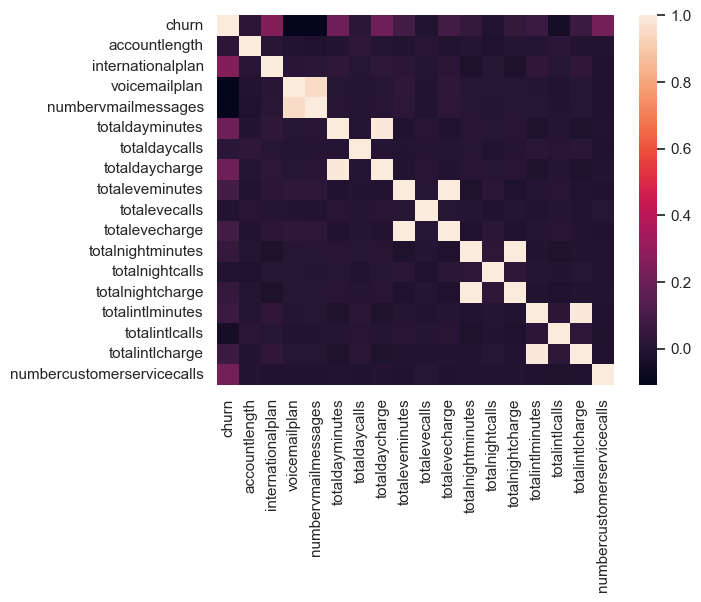

```python
def corr_target(df, to_corr):
    cor_mtx=df.filter(to_corr).corr()
    round(cor_mtx,64)
    sns.heatmap(cor_mtx)


to_corr = ['churn','accountlength','internationalplan','voicemailplan','numbervmailmessages','totaldayminutes','totaldaycalls','totaldaycharge','totaleveminutes',
    'totalevecalls','totalevecharge','totalnightminutes','totalnightcalls','totalnightcharge','totalintlminutes','totalintlcalls','totalintlcharge',
    'numbercustomerservicecalls']
corr_target(df, to_corr)
```

Verificou-se uma grande correlação entre as seguintes variáveis:

- 'totaldaycharge' e 'totaldayminutes';
- 'totalevecharge' e 'totaleveminutes';
- 'totalnightcharge' e 'totalnightminutes';
- 'totalintlcharge' e 'totalintlminutes'.

Estas correlações são intuitivas pois quantos mais minutos se usam mais é cobrado.

```python
colunas_correlacao = ['totaldaycharge', 'totaldayminutes',
                      'totalevecharge', 'totaleveminutes',
                      'totalnightcharge', 'totalnightminutes',
                      'totalintlcharge', 'totalintlminutes']
```

```python
df[colunas_correlacao]
```

|  | totaldaycharge | totaldayminutes | totalevecharge | totaleveminutes | totalnightcharge | totalnightminutes | totalintlcharge | totalintlminutes |
| --- | --- | --- | --- | --- | --- | --- | --- | --- |
| 0 | 45.07 | 265.1 | 16.78 | 197.4 | 11.01 | 244.7 | 2.70 | 10.0 |
| 1 | 27.47 | 161.6 | 16.62 | 195.5 | 11.45 | 254.4 | 3.70 | 13.7 |
| 2 | 41.38 | 243.4 | 10.30 | 121.2 | 7.32 | 162.6 | 3.29 | 12.2 |
| 3 | 50.90 | 299.4 | 5.26 | 61.9 | 8.86 | 196.9 | 1.78 | 6.6 |
| 4 | 28.34 | 166.7 | 12.61 | 148.3 | 8.41 | 186.9 | 2.73 | 10.1 |
| ... | ... | ... | ... | ... | ... | ... | ... | ... |
| 4995 | 40.07 | 235.7 | 18.96 | 223.0 | 13.39 | 297.5 | 2.67 | 9.9 |
| 4996 | 31.31 | 184.2 | 21.83 | 256.8 | 9.61 | 213.6 | 3.97 | 14.7 |
| 4997 | 23.90 | 140.6 | 14.69 | 172.8 | 9.56 | 212.4 | 3.67 | 13.6 |
| 4998 | 32.10 | 188.8 | 14.59 | 171.7 | NaN | 224.4 | 2.30 | 8.5 |
| 4999 | 22.00 | 129.4 | 22.70 | 267.1 | 6.97 | 154.8 | 2.51 | 9.3 |

5000 rows × 8 columns

```python
#DataFrame contendo apenas as colunas selecionadas
df_correlacao = df[colunas_correlacao]

#correlação para cada par de colunas
correlacao_dia = df_correlacao[['totaldaycharge', 'totaldayminutes']].corr().iloc[0, 1]
correlacao_total = df_correlacao[['totalevecharge', 'totaleveminutes']].corr().iloc[0, 1]
correlacao_noite = df_correlacao[['totalnightcharge', 'totalnightminutes']].corr().iloc[0, 1]
correlacao_internacional = df_correlacao[['totalintlcharge', 'totalintlminutes']].corr().iloc[0, 1]

#DataFrame com os resultados
df_resultado_correlacao = pd.DataFrame({
    'Par de Colunas': ['totaldaycharge e totaldayminutes',
                       'totalevecharge e totaleveminutes',
                       'totalnightcharge e totalnightminutes',
                       'totalintlcharge e totalintlminutes'],
    'Correlação': [correlacao_dia, correlacao_total, correlacao_noite, correlacao_internacional]
})

df_resultado_correlacao
```

|  | Par de Colunas | Correlação |
| --- | --- | --- |
| 0 | totaldaycharge e totaldayminutes | 0.992380 |
| 1 | totalevecharge e totaleveminutes | 1.000000 |
| 2 | totalnightcharge e totalnightminutes | 0.999999 |
| 3 | totalintlcharge e totalintlminutes | 0.994521 |

Tendo em vista que as correlações entre estas variáveis são altíssimas, é importante encontrar qual a relação entre as colunas, a fim de que a interferência destas não seja redundante na modelagem.

Foram criadas novas colunas para cada par de colunas correlacionadas chamadas, 'day_charge_per_minute', 'eve_charge_per_minute', 'night_charge_per_minute', 'intl_charge_per_minute', que representam as taxas de cobrança por minuto para cada uma das categorias.

```python
df['day_charge_per_minute'] = df['totaldaycharge'] / df['totaldayminutes']
df['eve_charge_per_minute'] = df['totalevecharge'] / df['totaleveminutes']
df['night_charge_per_minute'] = df['totalnightcharge'] / df['totalnightminutes']
df['intl_charge_per_minute'] = df['totalintlcharge'] / df['totalintlminutes']
df[['day_charge_per_minute', 'eve_charge_per_minute', 'night_charge_per_minute', 'intl_charge_per_minute']]
```

|  | day_charge_per_minute | eve_charge_per_minute | night_charge_per_minute | intl_charge_per_minute |
| --- | --- | --- | --- | --- |
| 0 | 0.170011 | 0.085005 | 0.044994 | 0.270000 |
| 1 | 0.169988 | 0.085013 | 0.045008 | 0.270073 |
| 2 | 0.170008 | 0.084983 | 0.045018 | 0.269672 |
| 3 | 0.170007 | 0.084976 | 0.044997 | 0.269697 |
| 4 | 0.170006 | 0.085030 | 0.044997 | 0.270297 |
| ... | ... | ... | ... | ... |
| 4995 | 0.170004 | 0.085022 | 0.045008 | 0.269697 |
| 4996 | 0.169978 | 0.085008 | 0.044991 | 0.270068 |
| 4997 | 0.169986 | 0.085012 | 0.045009 | 0.269853 |
| 4998 | 0.170021 | 0.084974 | NaN | 0.270588 |
| 4999 | 0.170015 | 0.084987 | 0.045026 | 0.269892 |

5000 rows × 4 columns

Como é possível perceber,

- 'totaldaycharge' é aproximadamente 0.17 * 'totaldayminutes',
- 'totalevecharge' é aproximadamente 0.085 * 'totaleveminutes',
- 'totalnightcharge' é aproximadamente 0.045 * 'totalnightminutes',
- 'totalintlcharge' é aproximadamente 0.27 * 'totalintlminutes'.

Isso significa que 'totaldaycharge', 'totalevecharge', 'totalnightcharge' e 'totalintlcharge' são colunas que contêm informação redundante e por isso foram posteriormente removidas.

### Visualização das distribuições das variáveis correlacionadas

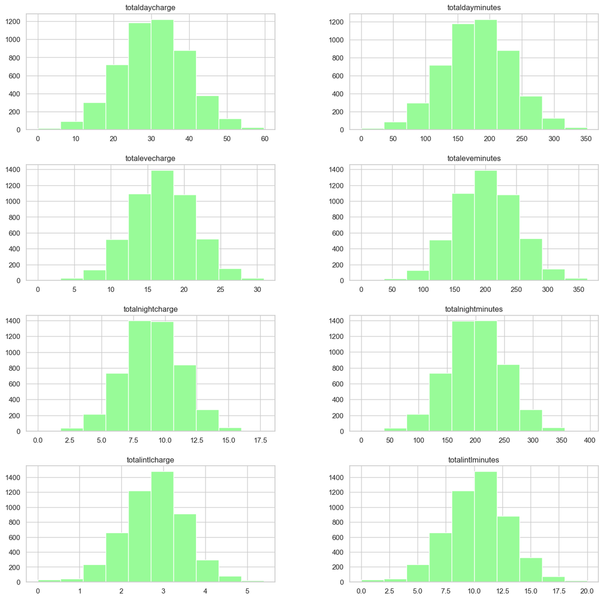

```python
df[colunas_correlacao].hist(figsize=(16,16), color='#98fb98', layout=(4, 2));
```

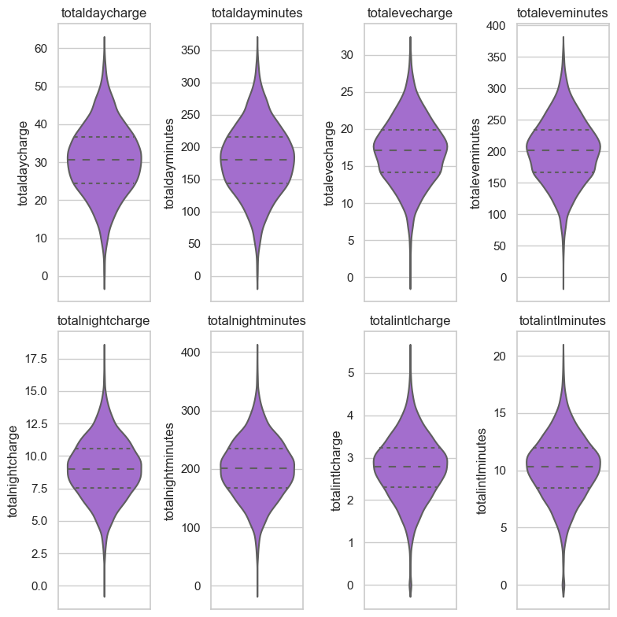

```python
plt.figure(figsize=(8, 8))
sns.set(style="whitegrid")
for i, coluna in enumerate(colunas_correlacao, 1):
    plt.subplot(2, 4, i)
    sns.violinplot(y=coluna, data=df, inner='quartile', color = '#A55EDD')
    plt.title(coluna)

plt.tight_layout()
plt.show();
```

### Missing values

Utilizamos o pacote Missingno para analisar o tipo de missing values contidos no dataset. A visualização em baixo mostra que provavelmente os missing values são completamente aleatórios (MCAR). Como estes valores parecem não apresentar grande correlação entre si, o valor de tendência central é o mais recomendado para a imputação destes valores.

Poderíamos ter excluido todas as linhas que contenham qualquer tipo de valor em falta (listwise deletion), contudo optou-se por ignorar essas observações, considerando que poderão ter alguma informação relevante que não deve ser descartada.

```python
df = df.drop(['day_charge_per_minute', 'eve_charge_per_minute',
            'night_charge_per_minute', 'intl_charge_per_minute'], axis=1)
```

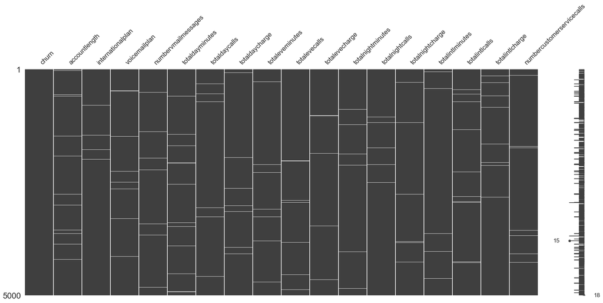

```python
#instalar missingno - pip install missingno
import missingno as msno
msno.matrix(df)
```

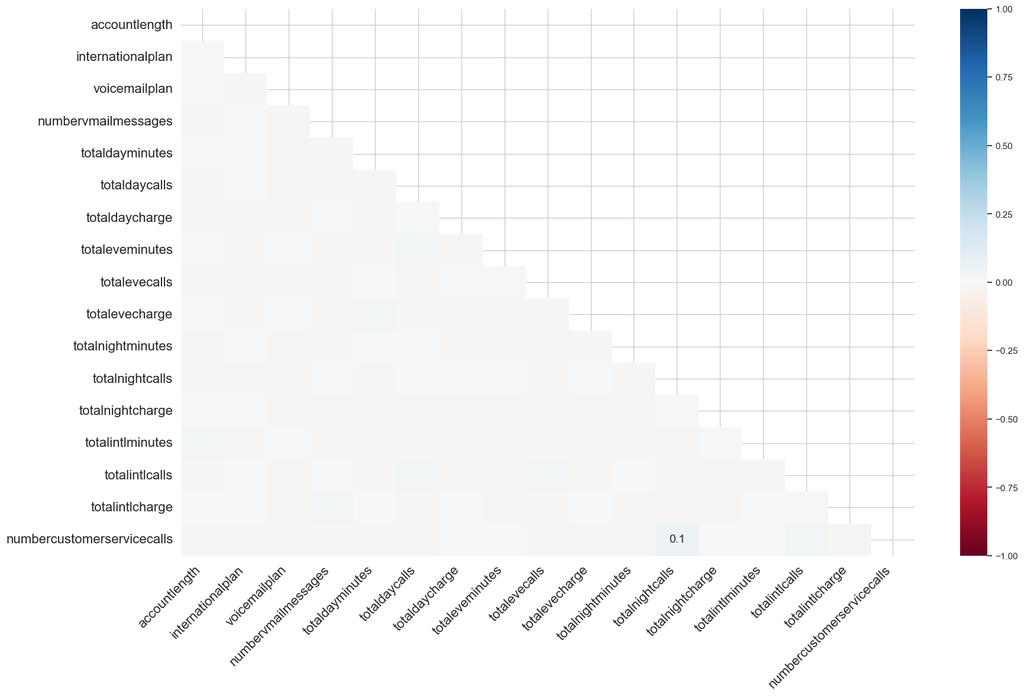

```python
msno.heatmap(df)
```

De facto não se verificou correlação significativa entre os missing values.

# Data Pre-Processing

## Inputação de valores

- Para as variáveis não correlacionadas, utilizou-se a mediana.
- Para as correlacionadas, utilizou-se a fórmula correspondente de acordo com a correlação encontrada entre as variáveis.

### Imputação de valores com a mediana:

```python
df_num_median = pd.DataFrame(df_num.median())
df_num_median
```

|  | 0 |
| --- | --- |
| accountlength | 100.00 |
| numbervmailmessages | 0.00 |
| totaldayminutes | 180.10 |
| totaldaycalls | 100.00 |
| totaldaycharge | 30.60 |
| totaleveminutes | 201.00 |
| totalevecalls | 101.00 |
| totalevecharge | 17.09 |
| totalnightminutes | 200.55 |
| totalnightcalls | 100.00 |
| totalnightcharge | 9.01 |
| totalintlminutes | 10.30 |
| totalintlcalls | 4.00 |
| totalintlcharge | 2.78 |
| numbercustomerservicecalls | 1.00 |

```python
df_fill = df
```

```python
pd.set_option('mode.chained_assignment', None)

#preenchimento dos missing values com a mediana
df_fill['accountlength'].fillna(df_num_median.iloc[0, 0], inplace=True)
df_fill['numbervmailmessages'].fillna(df_num_median.iloc[1, 0], inplace=True)

df_fill['totaldaycalls'].fillna(df_num_median.iloc[3, 0], inplace=True)
df_fill['totaldaycharge'].fillna(df_num_median.iloc[4, 0], inplace=True)

df_fill['totalevecalls'].fillna(df_num_median.iloc[6, 0], inplace=True)
df_fill['totalevecharge'].fillna(df_num_median.iloc[7, 0], inplace=True)

df_fill['totalnightcalls'].fillna(df_num_median.iloc[9, 0], inplace=True)
df_fill['totalnightcharge'].fillna(df_num_median.iloc[10, 0], inplace=True)

df_fill['totalintlcalls'].fillna(df_num_median.iloc[12, 0], inplace=True)
df_fill['totalintlcharge'].fillna(df_num_median.iloc[13, 0], inplace=True)
df_fill['numbercustomerservicecalls'].fillna(df_num_median.iloc[14, 0], inplace=True)


#preenchimento dos missing values de acordo com a correlação encontrada
df_fill['totaldayminutes'].fillna((df_fill['totaldaycharge']/0.17), inplace=True)
df_fill['totaleveminutes'].fillna((df_fill['totalevecharge']/0.085), inplace=True)
df_fill['totalnightminutes'].fillna((df_fill['totalnightcharge']/0.045), inplace=True)
df_fill['totalintlminutes'].fillna((df_fill['totalintlcharge']/0.27), inplace=True)
```

```python
df_fill.info()
```

```
<class 'pandas.core.frame.DataFrame'>
RangeIndex: 5000 entries, 0 to 4999
Data columns (total 18 columns):
 #   Column                      Non-Null Count  Dtype
---  ------                      --------------  -----
 0   churn                       5000 non-null   int64
 1   accountlength               5000 non-null   float64
 2   internationalplan           4950 non-null   float64
 3   voicemailplan               4950 non-null   float64
 4   numbervmailmessages         5000 non-null   float64
 5   totaldayminutes             5000 non-null   float64
 6   totaldaycalls               5000 non-null   float64
 7   totaldaycharge              5000 non-null   float64
 8   totaleveminutes             5000 non-null   float64
 9   totalevecalls               5000 non-null   float64
 10  totalevecharge              5000 non-null   float64
 11  totalnightminutes           5000 non-null   float64
 12  totalnightcalls             5000 non-null   float64
 13  totalnightcharge            5000 non-null   float64
 14  totalintlminutes            5000 non-null   float64
 15  totalintlcalls              5000 non-null   float64
 16  totalintlcharge             5000 non-null   float64
 17  numbercustomerservicecalls  5000 non-null   float64
dtypes: float64(17), int64(1)
memory usage: 703.3 KB
```

### Distribuição das variáveis numéricas sem missing values

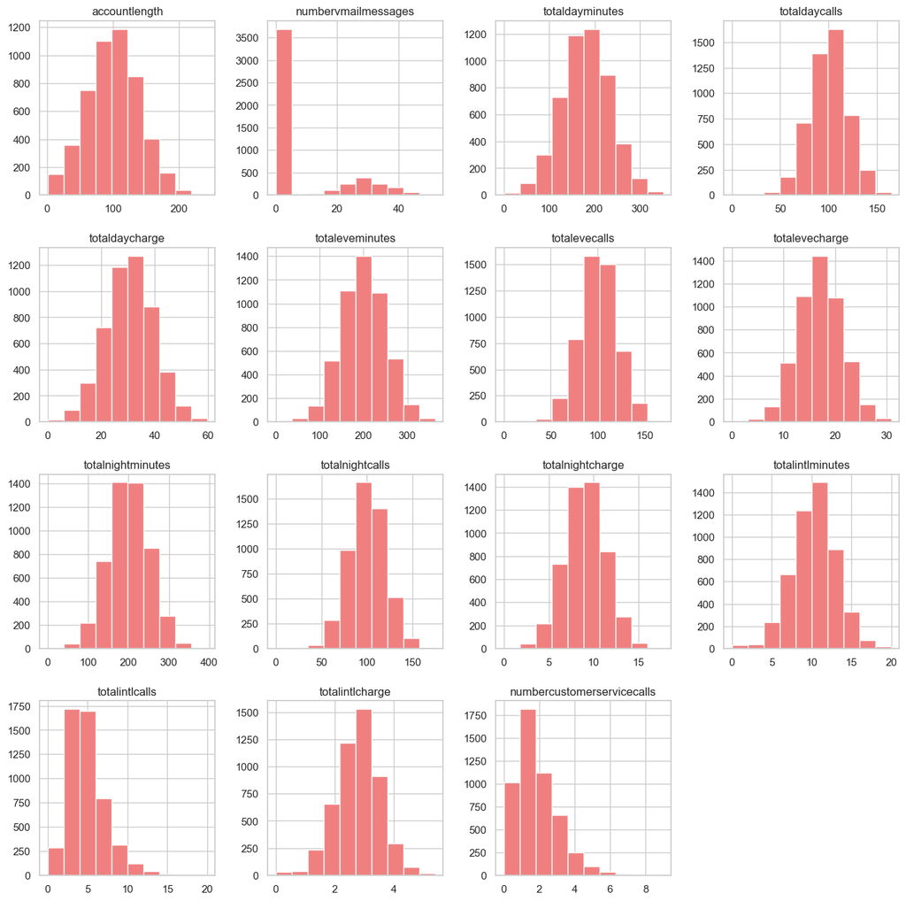

```python
df_fill[['accountlength', 'numbervmailmessages', 'totaldayminutes', 'totaldaycalls', 'totaldaycharge', 'totaleveminutes',
               'totalevecalls', 'totalevecharge', 'totalnightminutes', 'totalnightcalls', 'totalnightcharge', 'totalintlminutes',
              'totalintlcalls', 'totalintlcharge', 'numbercustomerservicecalls']].hist(figsize=(16,16), color='lightcoral');
```

### Violin plots: dataset com NANs imputados (df_fill):

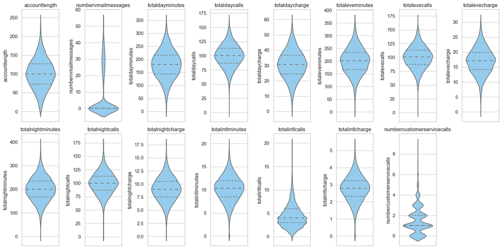

```python
# Criando violin plots do dataset df_fill
plt.figure(figsize=(16, 8))
sns.set(style="whitegrid")
for i, coluna in enumerate(colunas, 1):
    plt.subplot(2, 8, i)
    sns.violinplot(y=coluna, data=df_fill, inner='quartile', color = 'lightskyblue')
    plt.title(coluna)

plt.tight_layout()
plt.show()
```

### Eliminação de colunas redundantes

```python
df_fill = df_fill.drop(['totaldaycharge', 'totalevecharge',
                        'totalnightcharge', 'totalintlcharge'], axis=1)
```

```python
df_fill.info()
```

```
<class 'pandas.core.frame.DataFrame'>
RangeIndex: 5000 entries, 0 to 4999
Data columns (total 14 columns):
 #   Column                      Non-Null Count  Dtype
---  ------                      --------------  -----
 0   churn                       5000 non-null   int64
 1   accountlength               5000 non-null   float64
 2   internationalplan           4950 non-null   float64
 3   voicemailplan               4950 non-null   float64
 4   numbervmailmessages         5000 non-null   float64
 5   totaldayminutes             5000 non-null   float64
 6   totaldaycalls               5000 non-null   float64
 7   totaleveminutes             5000 non-null   float64
 8   totalevecalls               5000 non-null   float64
 9   totalnightminutes           5000 non-null   float64
 10  totalnightcalls             5000 non-null   float64
 11  totalintlminutes            5000 non-null   float64
 12  totalintlcalls              5000 non-null   float64
 13  numbercustomerservicecalls  5000 non-null   float64
dtypes: float64(13), int64(1)
memory usage: 547.0 KB
```

### Método SMOTE-ENN¶

As técnicas de SMOTE são especialmente desenhadas para tratar de datasets desiquilibrados, gerando dados sintéticos para a classe minoritária. Usamos o método SMOTE-ENN que combina SMOTE com ENN (Edited Nearest Neighbor). Foi definido y como a variável alvo(target) e X o restante dataset, com as variáveis independentes(features).

```python
from imblearn.pipeline import Pipeline
import matplotlib.pyplot as plt
from sklearn.datasets import make_classification
from sklearn.model_selection import cross_validate
from sklearn.model_selection import RepeatedStratifiedKFold
from sklearn.model_selection import train_test_split
from sklearn.ensemble import AdaBoostClassifier
from imblearn.combine import SMOTEENN
from imblearn.under_sampling import EditedNearestNeighbours

X = df_fill[['accountlength', 'numbervmailmessages', 'totaldayminutes', 'totaldaycalls','totaleveminutes',
               'totalevecalls', 'totalnightminutes', 'totalnightcalls', 'totalintlminutes',
              'totalintlcalls', 'numbercustomerservicecalls']]
y = np.array(df_fill['churn'])
```

# Modeling

```python
# Assume X and y are your feature matrix and target variable
X_train, X_test, y_train, y_test = train_test_split(X, y, test_size=0.2, random_state=42)
```

### Ensemble AdaBoost (Adaptive Boosting) no dataset original

```python
model_1 = AdaBoostClassifier()

cv_1 =RepeatedStratifiedKFold(n_splits=10, n_repeats=3, random_state=1)
#Evaluate model
scoring=['accuracy','precision_macro','recall_macro']
scores_1 = cross_validate(model_1, X_train, y_train, scoring=scoring, cv=cv_1, n_jobs=-1)

# summarize performance
print('Mean Accuracy: %.4f' % np.mean(scores_1['test_accuracy']))
print('Mean Precision: %.4f' % np.mean(scores_1['test_precision_macro']))
print('Mean Recall: %.4f' % np.mean(scores_1['test_recall_macro']))
```

```
Mean Accuracy: 0.8737
Mean Precision: 0.7520
Mean Recall: 0.6439
```

### Ensemble AdaBoost (Adaptive Boosting) usando SMOTE-ENN

```python
##Using SMOTE-ENN to balance the data
#Define model
model_balanced=AdaBoostClassifier()
#Define SMOTE-ENN
resample=SMOTEENN(enn=EditedNearestNeighbours(sampling_strategy='all'))
#Define pipeline
pipeline=Pipeline(steps=[('r', resample), ('m', model_balanced)])
#Define evaluation procedure (here we use Repeated Stratified K-Fold CV)
cv=RepeatedStratifiedKFold(n_splits=10, n_repeats=3, random_state=1)
#Evaluate model
scoring=['accuracy','precision_macro','recall_macro']
scores = cross_validate(pipeline, X_train, y_train, scoring=scoring, cv=cv, n_jobs=-1)

# summarize performance
print('Mean Accuracy: %.4f' % np.mean(scores['test_accuracy']))
print('Mean Precision: %.4f' % np.mean(scores['test_precision_macro']))
print('Mean Recall: %.4f' % np.mean(scores['test_recall_macro']))
```

```
Mean Accuracy: 0.8102
Mean Precision: 0.6658
Mean Recall: 0.7403
```

### Linear Regression

Neste dataset em específico, existe um problema de classificação. O intuito é conseguir classificar se uma nova entrada para "Churn?" será "Yes" ou "No", dependendo dos valores das variáveis explicatórias. Devido a isto, não faz sentido implementar um modelo de regressão linear.

### Naive Bayes

```python
from sklearn.naive_bayes import CategoricalNB

modelNB=CategoricalNB()
modelNB.fit(X_train,y_train)
```

```
CategoricalNB()
```

### Avaliação

```python
##Using SMOTE-ENN to balance the data
#Define model
predsNB = modelNB.predict(X_train)
#Define SMOTE-ENN
resample=SMOTEENN(enn=EditedNearestNeighbours(sampling_strategy='all'))
#Define pipeline
pipeline=Pipeline(steps=[('r', resample), ('m', model_balanced)])
#Define evaluation procedure (here we use Repeated Stratified K-Fold CV)
cv=RepeatedStratifiedKFold(n_splits=10, n_repeats=3, random_state=1)
#Evaluate model
scoring=['accuracy','precision_macro','recall_macro']
scores = cross_validate(pipeline, X_train, y_train, scoring=scoring, cv=cv, n_jobs=-1)

# summarize performance
print('Mean Accuracy: %.4f' % np.mean(scores['test_accuracy']))
print('Mean Precision: %.4f' % np.mean(scores['test_precision_macro']))
print('Mean Recall: %.4f' % np.mean(scores['test_recall_macro']))
```

```
Mean Accuracy: 0.8146
Mean Precision: 0.6709
Mean Recall: 0.7468
```

### Decision Trees

```python
from sklearn.tree import DecisionTreeClassifier
from sklearn import tree
from sklearn.model_selection import train_test_split
from sklearn.metrics import accuracy_score

X1, X2, y1, y2 = train_test_split(X, y, train_size=0.8)

# we define a function to make repetition easier
# the function obtains the accuracy on the test set for a given split and tree depth
def depth2acc(X1,X2,y1,y2,max_depth=None):
    modelDT=tree.DecisionTreeClassifier(max_depth=max_depth)
    modelDT.fit(X1,y1)
    yhat=modelDT.predict(X2)
    return accuracy_score(y2,yhat)
```

### Avaliação

```
Accuracy:  1 0.86
Accuracy:  2 0.871
Accuracy:  3 0.895
Accuracy:  5 0.907
Accuracy:  7 0.918
Accuracy:  10 0.9
Accuracy:  15 0.881
Accuracy:  20 0.876
Accuracy:  30 0.869
Accuracy:  40 0.862
Accuracy:  50 0.87
Accuracy:  60 0.862
Accuracy:  70 0.876
Accuracy:  100 0.867
```

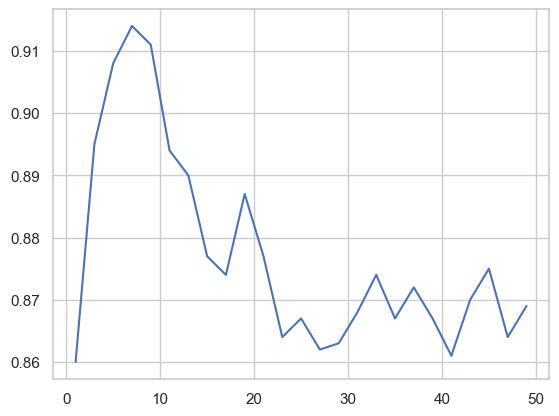

```python
#accuracy
for i in [1,2,3,5,7,10,15,20,30,40,50,60,70,100]:
    print("Accuracy: ",i,depth2acc(X1,X2,y1,y2,i))

from matplotlib.pyplot import plot

depths=range(1,50,2)
accs=list(map(lambda i:depth2acc(X1,X2,y1,y2,i),depths))
plot(depths,accs);
```

A melhor accuracy foi conseguida com um max_depth de 7.

## K-nearest Neighbours

```python
from sklearn.neighbors import KNeighborsClassifier
from sklearn.model_selection import cross_val_score

def k2acc(X, y, n_neighbours):
    modelKNN = KNeighborsClassifier(n_neighbors=n_neighbours)
    modelKNN.fit(X_train, y_train)
    score=cross_val_score(modelKNN, X_train, y_train, cv=10)
    mean=np.mean(score)
    return mean
```

```python
high_score =0
high_score_posix = 0
for i in range(1,50,2):
    mean = k2acc(X_train , y_train ,i)
    print("mean of the scores for k=",i,mean)
    if mean > high_score:
        high_score_posix = i
        high_score = mean
```

```
mean of the scores for k= 1 0.8195
mean of the scores for k= 3 0.86825
mean of the scores for k= 5 0.88125
mean of the scores for k= 7 0.8862500000000001
mean of the scores for k= 9 0.8880000000000001
mean of the scores for k= 11 0.88575
mean of the scores for k= 13 0.8845000000000001
mean of the scores for k= 15 0.8845000000000001
mean of the scores for k= 17 0.884
mean of the scores for k= 19 0.88425
mean of the scores for k= 21 0.8835000000000001
mean of the scores for k= 23 0.883
mean of the scores for k= 25 0.883
mean of the scores for k= 27 0.8825
mean of the scores for k= 29 0.88125
mean of the scores for k= 31 0.8800000000000001
mean of the scores for k= 33 0.8800000000000001
mean of the scores for k= 35 0.8792500000000001
mean of the scores for k= 37 0.8795
mean of the scores for k= 39 0.8782500000000001
mean of the scores for k= 41 0.8782500000000001
mean of the scores for k= 43 0.8775000000000001
mean of the scores for k= 45 0.87675
mean of the scores for k= 47 0.8760000000000001
mean of the scores for k= 49 0.8752500000000001
```

```python
print(f"A melhor score foi de {high_score}, obtida na posição {high_score_posix}")
```

```
A melhor score foi de 0.8880000000000001, obtida na posição 9
```

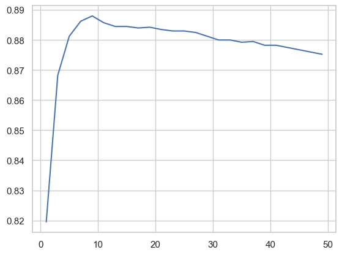

```python
n_neighbours=range(1,50,2)
scores=list(map(lambda i:k2acc(X,y,i),n_neighbours))
plot(n_neighbours,scores);
```